# Final Project

## Top scorers under the average amount of minutes

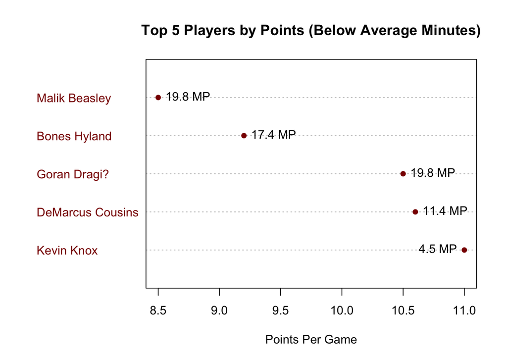

```r
# Filter the data for players who have played under 20 minutes per game
filtered_data <- nba_data[nba_data$MP < 20,]

# Sort the filtered data by PTS (make sure 'PTS' is numeric)
filtered_data$PTS <- as.numeric(filtered_data$PTS)
sorted_data <- filtered_data[order(-filtered_data$PTS),]

# Select the top 5 players
top_5_players <- head(sorted_data, 5)

# Sort the filtered data by PTS (make sure 'PTS' is numeric)
filtered_data$PTS <- as.numeric(filtered_data$PTS)
sorted_data <- filtered_data[order(-filtered_data$PTS),]

# Select the top 5 players
top_5_players <- head(sorted_data, 5)

# Create a dotplot of PTS with minutes per game for the top 5 players
dotchart(top_5_players$PTS, labels = top_5_players$Player, cex = 1,
         main = "Top 5 Players by Points (Below Average Minutes)",
         xlab = "Points Per Game", ylab = "",
         pch = 16, col = "darkred")

# Add text labels for minutes per game
text(top_5_players$PTS, seq_along(top_5_players$Player), labels = paste(top_5_players$MP, "MP"),
     pos = ifelse(seq_along(top_5_players$Player) == 1, 2, 4), col = "black")
```

In the last part of my research, I focused on basketball players who don’t play as much as the average in the NBA. I wanted to see which players score the most points in a game even though they spend less than 20 minutes (average amount of minutes per game in the NBA) on the court. After looking at the stats, I found the top five players who fit this criteria. This shows that these players bring something special to the game, proving that you don’t need a lot of time on the court to make a big impact in basketball.  
In this dotplot, each dot represents the average points per game scored by each player and their average amount of minutes per game (MP).

## **Conclusion**

In this exploration project, we delved into the individual player statistics of the 2021 NBA Playoffs, aiming to identify the top performers in four crucial basketball categories: points, assists, rebounds, and blocks. Additionally, we focused on players’ performances in the NBA Finals and examined the contributions of those playing under the average minutes per game.